# STATS 326/786 — Lab 03 Model Answer

Week 3 Tutorial

# Problem 1 — Australian Retail Turnover

## Setup — Selecting a Time Series

We filter to a single series: **Queensland — Takeaway food services**. Any valid series is acceptable; the commentary below is specific to this choice.

```r
d <- aus_retail %>%
  filter(State    == "Queensland",
         Industry == "Takeaway food services")
```

## Part 1 — Time Plot

> Select one time series, plot it, and comment on what you observe.

### Solution

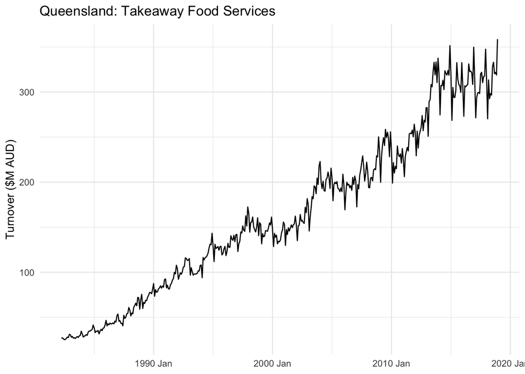

```r
d %>%
  autoplot(Turnover) +
  labs(title = "Queensland: Takeaway Food Services",
       y = "Turnover ($M AUD)", x = NULL) +
  theme_minimal()
```

### Explanation

[output not shown]

**Additive vs multiplicative seasonality:** When the size of seasonal swings grows proportionally with the level of the series, the seasonality is **multiplicative**. This matters for choosing an appropriate decomposition method (e.g., multiplicative STL or log-transformation before fitting an additive model).

## Part 2 — Seasonal & Subseries Plots

> Create a seasonal plot and a seasonal subseries plot. Comment on any interesting patterns.

### Solution

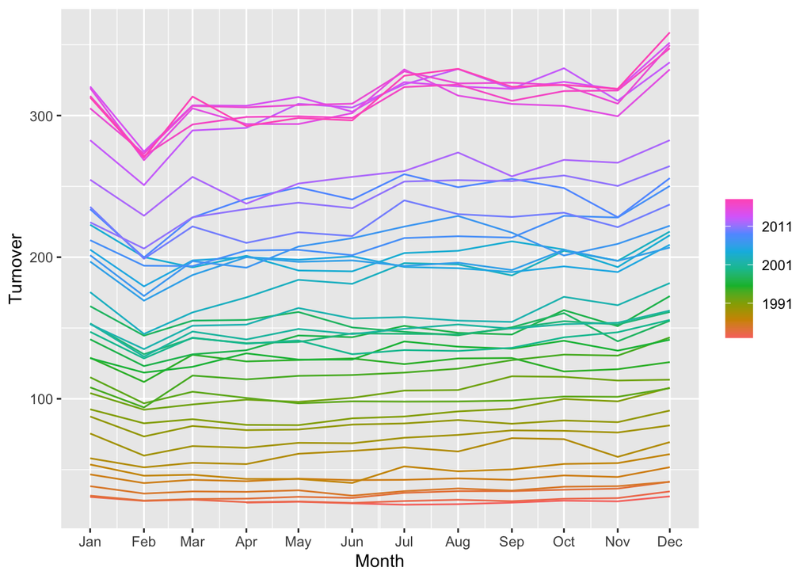

```r
d %>% gg_season(Turnover)
```

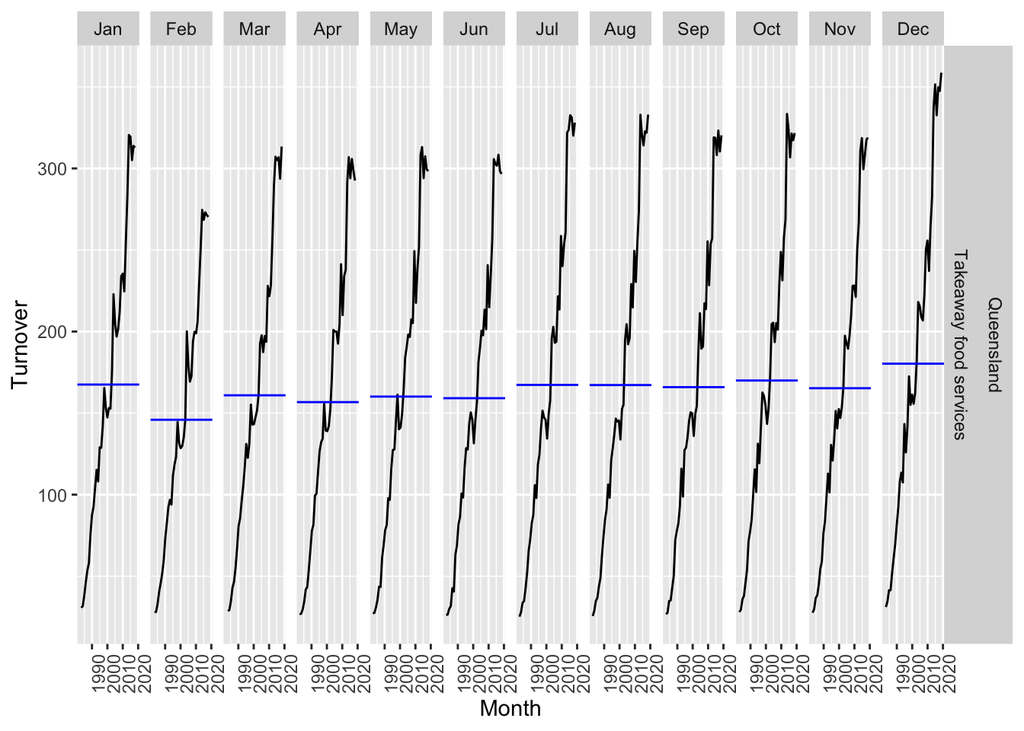

```r
d %>% gg_subseries(Turnover)
```

### Explanation

**Seasonal plot (`gg_season`):**

- Each coloured line is one year.
- The peak occurs in **December–January** (Australian summer holiday period), and the trough in **February**.
- The year-on-year increase is visible — later years (lighter colours) sit above earlier years throughout.

**Why is February low?** Partly because February has fewer days — this motivates the calendar adjustment in the next part.

## Part 3 — Calendar Adjustment

> Make a calendar adjustment and re-plot the seasonal plots. Discuss whether there is a calendar effect.

### Solution

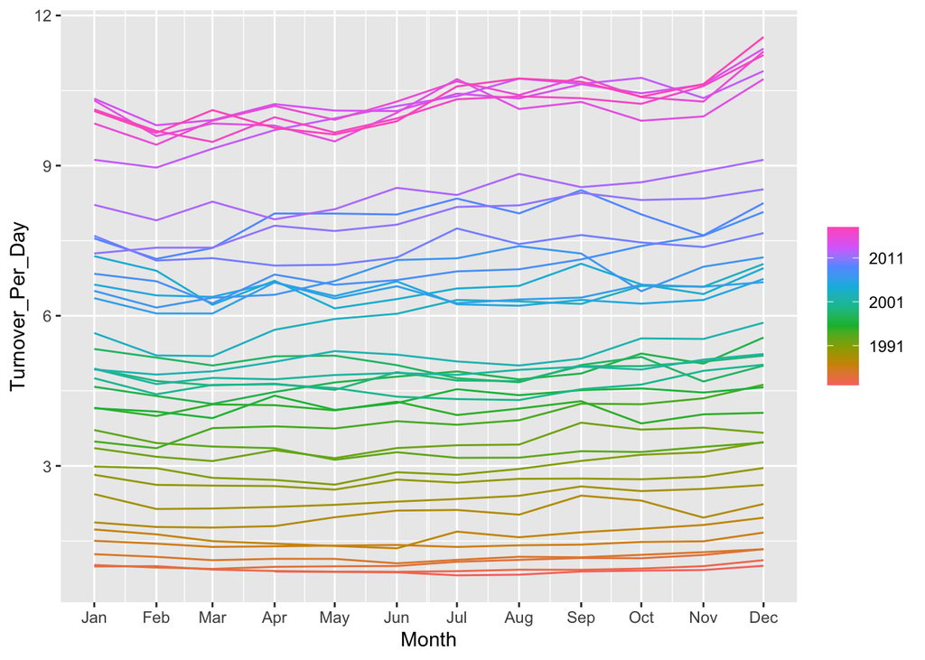

```r
d <- d %>%
  mutate(Days            = days_in_month(Month),
         Turnover_Per_Day = Turnover / Days)

d %>% gg_season(Turnover_Per_Day)
```

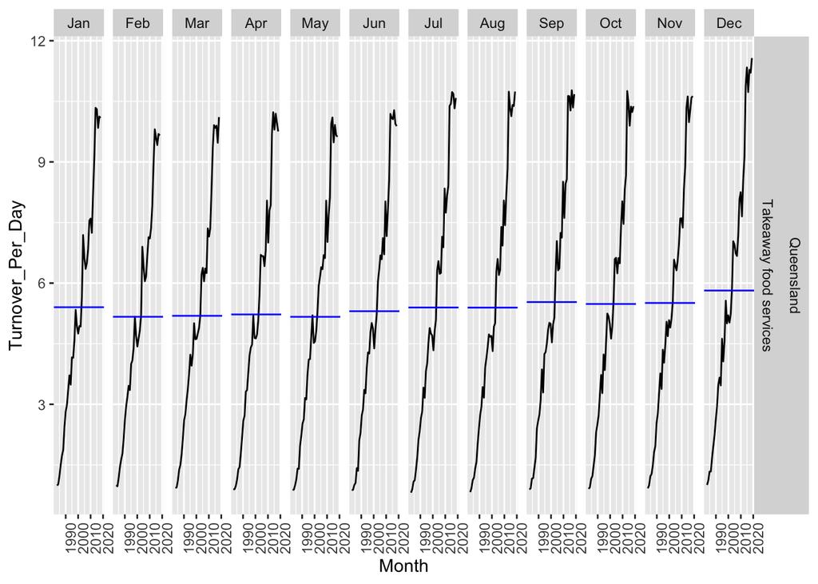

```r
d %>% gg_subseries(Turnover_Per_Day)
```

### Explanation

| Variable | Meaning |
| --- | --- |
| `days_in_month(Month)` | Number of days in each month (28/29/30/31) |
| `Turnover / Days` | Average daily turnover — removes the “more days = more sales” effect |

**Is there a calendar effect?** Yes.

- In the subseries plot, February’s mean **rises** relative to March once we divide by days, closing most of the gap with the surrounding months.
- April, September, and November (30-day months) also shift slightly upward relative to the 31-day months.
- This confirms that part of February’s apparent low turnover was simply due to it having fewer days, not genuinely lower daily trading activity.

## Part 4 — Box-Cox Transformation

> Perform a Box-Cox transformation on the calendar-adjusted series. What is the optimal $\lambda$?

### Solution

```r
lambda <- d %>%
  features(Turnover_Per_Day, features = guerrero) %>%
  pull(lambda_guerrero)
lambda
```

```
## [1] 0.2866775
```

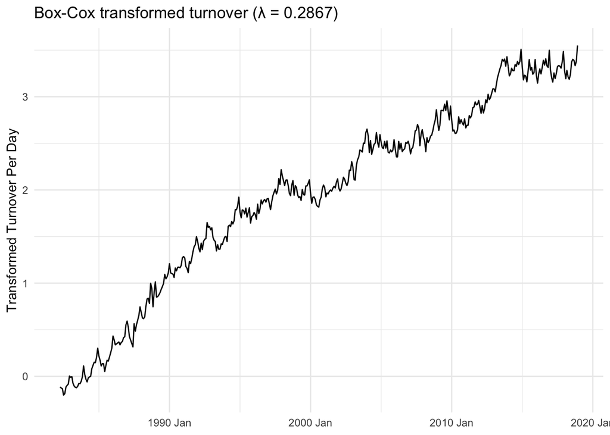

```r
d %>%
  autoplot(box_cox(Turnover_Per_Day, lambda)) +
  labs(title    = sprintf("Box-Cox transformed turnover (λ = %.4f)", lambda),
       y = "Transformed Turnover Per Day", x = NULL) +
  theme_minimal()
```

### Explanation

**Box-Cox family:**

$$w_t = \begin{cases}
\log(y_t) & \lambda = 0 \\
\dfrac{y_t^{\lambda} - 1}{\lambda} & \lambda \neq 0
\end{cases}$$

- The **Guerrero method** selects $\lambda$ to minimise the coefficient of variation of the subseries means — i.e., it looks for the $\lambda$ that makes the seasonal variation most stable across the level of the series.
- For this Queensland takeaway series the optimal $\lambda \approx 0.29$, which is close to (but not exactly) a log transform ($\lambda = 0$).
- The transformed series shows more stable variance across time, which is the goal: multiplicative seasonality becomes approximately additive after transformation.

**Practical tip:** Values of $\lambda$ close to 0 are often rounded to 0 (log) for interpretability. Here, $\lambda \approx 0.29$ is close enough that a log transform would also be reasonable.

# Problem 2 — White Noise

## Setup

```r
set.seed(12345)
year <- 1900:2024
T    <- length(year)
data <- tsibble(year = year,
                y    = rnorm(T),
                index = year)
```

> **Note:** The solutions file adds `set.seed(12345)` so that results are reproducible. The student version omits this, so individual plots will differ — but the *qualitative* conclusions should be the same.

## Part 1 — Time Plot

> Plot a time plot and comment on any features you observe.

### Solution

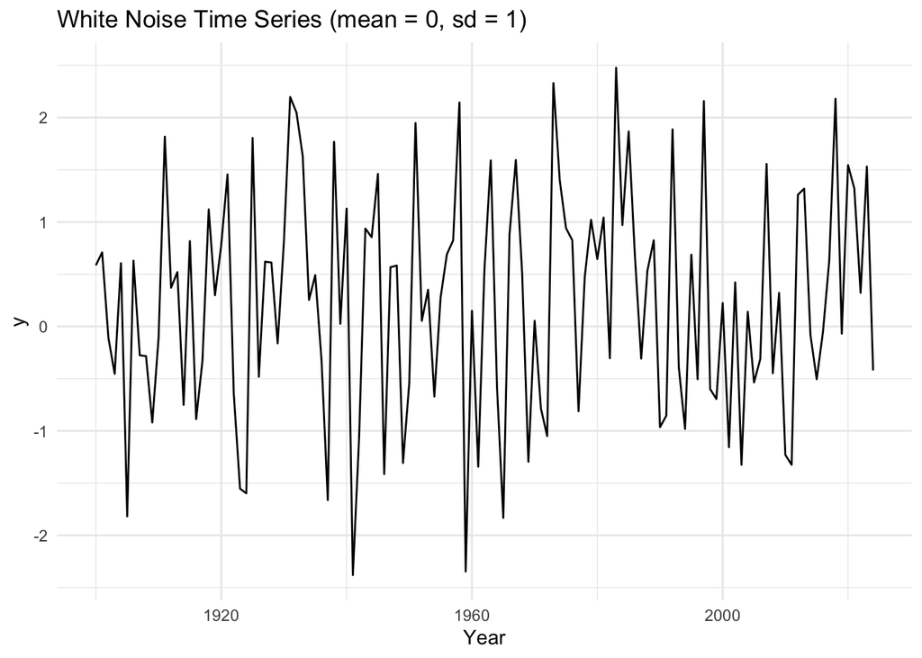

```r
data %>%
  autoplot(y) +
  labs(title = "White Noise Time Series (mean = 0, sd = 1)",
       y = "y", x = "Year") +
  theme_minimal()
```

### Explanation

| Feature | Observation |
| --- | --- |
| **Trend** | None — the series fluctuates around zero with no systematic direction |
| **Seasonality** | None — the data are annual so intra-year seasonality cannot exist |
| **Cycles** | None apparent |
| **Variance** | Roughly constant (homoscedastic) |
| **Range** | Approximately $[-2.5, 2.5]$, consistent with a standard Normal |

This is expected: the series was generated as i.i.d. $\mathcal{N}(0,1)$, so by construction there is no temporal structure.

## Part 2 — ACF Plot with Custom Significance Lines

> Plot the ACF, adding 90% significance lines in red. Hint: if `qnorm(0.975) = 1.96`, what is the new multiplier?

### Solution

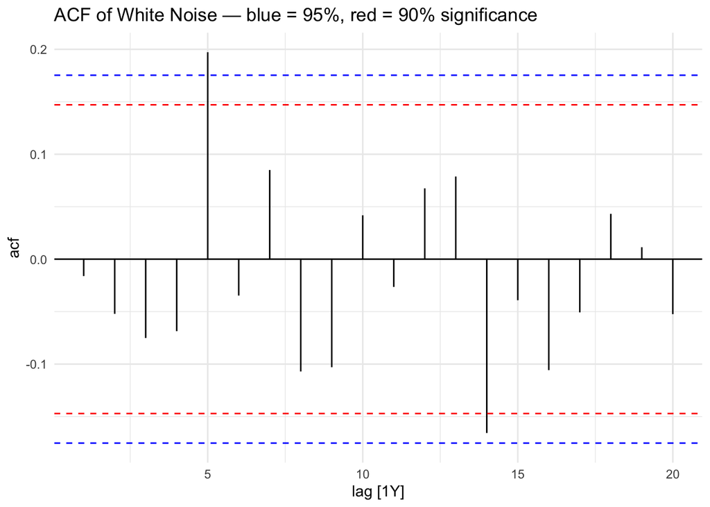

```r
data %>%
  ACF(y) %>%
  autoplot() +
  geom_hline(yintercept = c(-1, 1) * qnorm(0.95) / sqrt(T),
             colour = "red", linetype = "dashed") +
  labs(title = "ACF of White Noise — blue = 95%, red = 90% significance") +
  theme_minimal()
```

### Explanation

**Where do the significance lines come from?**

Under the null hypothesis that all autocorrelations are zero, each sample autocorrelation $\hat{\rho}_k$ is approximately $\mathcal{N}(0, 1/T)$ for large $T$. A two-sided $100(1-\alpha)\%$ significance band is therefore:

$$\pm \frac{z_{1-\alpha/2}}{\sqrt{T}}$$

| Level | $\alpha$ | $z_{1-\alpha/2}$ | R expression |
| --- | --- | --- | --- |
| 95% (default blue) | 0.05 | `qnorm(0.975)` $\approx 1.96$ | `1.96 / sqrt(T)` |
| 90% (red) | 0.10 | `qnorm(0.95)` $\approx 1.645$ | `qnorm(0.95) / sqrt(T)` |

**What to expect:** For a white noise series of length $T = 125$, we expect approximately 5% of the 95%-level bars to exceed the blue lines by chance alone, and 10% to exceed the narrower red lines.

## Part 3 — Lag Plot

> Produce a lag plot. Comment on why there is no colour. Comment on any patterns.

### Solution

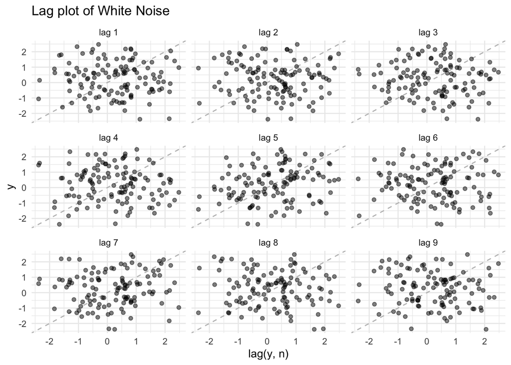

```r
data %>%
  gg_lag(y, geom = "point", alpha = 0.5) +
  labs(title = "Lag plot of White Noise") +
  theme_minimal()
```

### Explanation

**Why no colour?**

In `fpp3`, `gg_lag()` colours points by the **season** of the observation (e.g., month or quarter). This series has an **annual** index — there is only one observation per year and no sub-annual seasonality — so every observation belongs to the same “season” and a single colour is used throughout.

**What patterns do we observe?**

- There is **no discernible linear relationship** between $y_t$ and $y_{t-k}$ at any of the displayed lags.
- The point clouds are roughly circular (or formless), indicating near-zero autocorrelation at every lag.
- This is exactly what we expect from a white noise process: successive values are independent, so knowing $y_{t-k}$ tells us nothing about $y_t$.